# Homework 5: RMarkdown

Merab Gomez

3/5/2022

# Exploratory Data Analysis

This project has two raw data files at different scales from a study of infants, children, and adults watching a series of 7 video clips. I wrote Steps 1 and 2 to import and merge the data, and kept them here for your reference. Skip down to Step 3 to work on EDA.

## Source Description

### FILE 1: auc.csv

Columns:

- stim (stimulus video, levels/labels provided below)
- id (unique participant identifier)
- age (in days)
- AUC_sal (area-under-the-curve for a saliency model)
- AUC_dist (area-under-the-curve for a distance model)

AUC values indicate how well each model predicted where participants looked when watching a video. AUC values can range from 0-1 where .5 is chance and 1 is perfect prediction.

### FILE 2: participants_info_full_headers.csv

Columns:

- id (unique participant identifier, matches auc.csv)
- age_group (a categorical age variable with levels:
- “.5-1 y” “1-1.5 y” “1.5-2 y” “2-4 y” “4-6 y” “8-10 y” “adult”
- precision (a quality measure of the eye data, smaller is better)
- 7 columns of “Seen X” the stimulus video before the study coded as SEEN (1), NOT SEEN (2), NOT SURE (3)

## STEP 1: Read in AUC data

Code stim as a factor

```r
auc <- read_csv(here("data_raw", "auc_bystim.csv"))
stim_levels <- 1:7
stim_labels <- c("Fallon","Feist","Pentatonix","Science","Rube","Plane","Dogs")
auc <- auc %>% mutate(stim = factor(stim, levels = stim_levels, labels = stim_labels))
```

## STEP 2: Read in Participant Info Data

Wrangle the ppt info data so that you can merge it into the auc data. Drop any data where the AUC values are missing in the final, merged data, make the “watched” variable is coded as a factor with levels “seen” (1), “not seen” (2), “not sure” (3). Write the cleaned file to data_cleaned/

Read in the ppt data and rename columns to be easier to work with

```r
ppt <- read_csv(here("data_raw","participants_info_full_headers.csv")) %>%
  rename(id = `participant ID`,
         age_group = `Age group`,
         precision = "Precision")
```

Each question about watching each video is a column, so pivot_longer. Use separate to get just the video name into it’s own column.

```r
ppt_long <- ppt %>% pivot_longer(cols = starts_with("Seen"), names_to = "stim", values_to = "watched")
ppt_long <- ppt_long %>% separate(stim, into = c(NA, "stim"))
```

Code stim and watched as factors

```r
ppt_long <- ppt_long %>% mutate(
  stim = factor(stim, levels = stim_labels, labels = stim_labels),
  watched = factor(watched, levels = 1:3, labels = c("Yes","No","Not Sure")))
```

Join the ppt data to the AUC data (by id and by stim since each participant has observations for each stim).

```r
ds <- left_join(auc, ppt_long, by = c("id", "stim"))
ds <- ds %>% drop_na(AUC_sal:AUC_dist) #Drop participants for whom we don't have data for the DV
```

Write the data to file

```r
ds %>% write_csv(here("data_cleaned","cleaned.csv"))
```

## STEP 3: EXPLORATORY DATA ANALYSIS

### 3A Precision

Is the precision acceptable (< 2.5) for each participant? Visualize the distribution of precision to see if there are values above 2.5. Create a summary to figure out which participants would we need to exclude if > 2.5 meant the data are unuseable? Use a summary table and plots to investigate whether data equally precise for participants of different ages.

Visualize the distribution of precision to see if there are values above 2.5

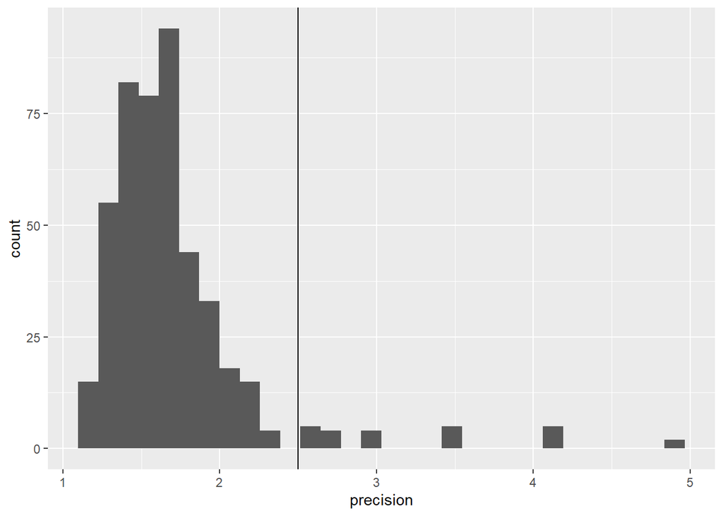

```r
ds %>% ggplot(aes(x = precision)) + geom_histogram() + geom_vline(xintercept = 2.5)
```

Create a summary to figure out which participants would we need to exclude if > 2.5 meant the data are unusable?

```r
ds %>% group_by(id, age_group) %>%
  summarize(precision = mean(precision, na.RM = T)) %>%
  filter(precision > 2.5)
```

```
## # A tibble: 6 x 3
## # Groups:   id [6]
##      id age_group precision
##   <dbl> <chr>         <dbl>
## 1    52 1-1.5 y        3.02
## 2    78 .5-1 y         3.45
## 3    79 .5-1 y         4.89
## 4    81 .5-1 y         2.68
## 5    84 4-6 y          2.64
## 6   108 .5-1 y         4.1
```

```r
ds %>% filter(precision > 2.5)
```

```
## # A tibble: 25 x 8
##    stim          id   age AUC_sal AUC_dist age_group precision watched
##    <fct>      <dbl> <dbl>   <dbl>    <dbl> <chr>         <dbl> <fct>
##  1 Feist         52   539   0.547    0.507 1-1.5 y        3.02 No
##  2 Science       52   539   0.447    0.356 1-1.5 y        3.02 No
##  3 Plane         52   539   0.498    0.484 1-1.5 y        3.02 No
##  4 Dogs          52   539   0.668    0.470 1-1.5 y        3.02 No
##  5 Feist         78   198   0.507    0.449 .5-1 y         3.45 No
##  6 Pentatonix    78   198   0.577    0.580 .5-1 y         3.45 No
##  7 Science       78   198   0.755    0.821 .5-1 y         3.45 No
##  8 Plane         78   198   0.611    0.555 .5-1 y         3.45 No
##  9 Dogs          78   198   0.494    0.485 .5-1 y         3.45 No
## 10 Feist         79   226   0.600    0.597 .5-1 y         4.89 No
## # ... with 15 more rows
```

Use a summary table and plots to investigate whether data equally precise for participants of different ages

```r
ds %>% group_by(age_group) %>% summarize(across(precision, list(M = mean, MIN = min, MAX = max)))
```

```
## # A tibble: 7 x 4
##   age_group precision_M precision_MIN precision_MAX
##   <chr>           <dbl>         <dbl>         <dbl>
## 1 .5-1 y           2.11          1.25          4.89
## 2 1-1.5 y          1.66          1.29          3.02
## 3 1.5-2 y          1.64          1.21          2.38
## 4 2-4 y            1.72          1.43          1.96
## 5 4-6 y            1.68          1.18          2.64
## 6 8-10 y           1.59          1.3           2.04
## 7 adult            1.50          1.15          1.99
```

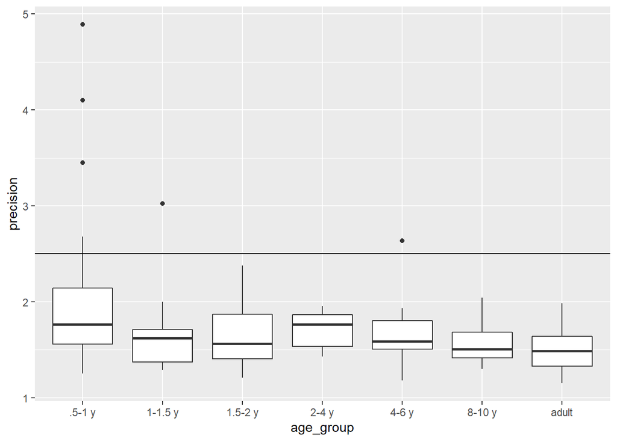

```r
ds %>% ggplot(aes(x = age_group, y = precision)) + geom_boxplot() + geom_hline(yintercept = 2.5)
```

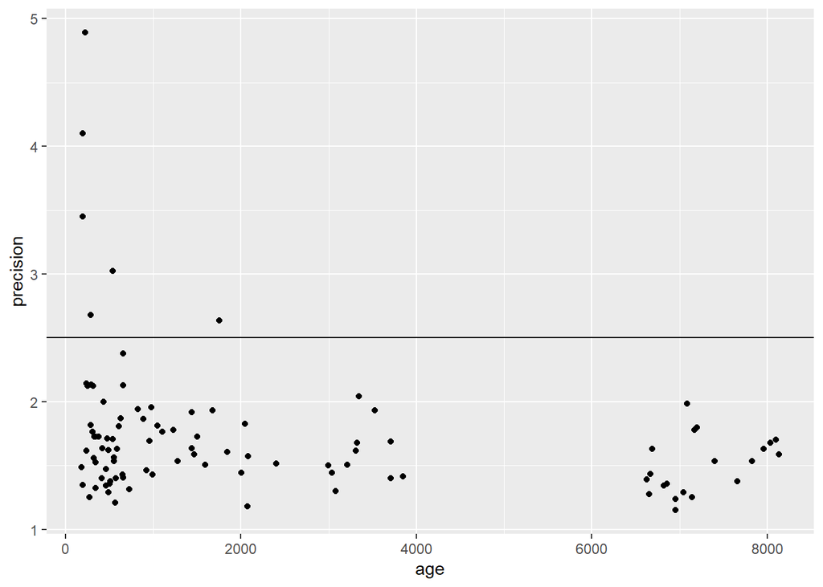

```r
ds %>% ggplot(aes(x = age, y = precision)) + geom_point() + geom_hline(yintercept = 2.5)
```

### 3B Age

Convert age to years so that it can be more easily compared to age_group. Visualize age in years by age_group to see whether participants are the correct age for their group. Make a summary table of age in years by age group to check whether all participants’ ages are correct

Convert age to years so that it can be more easily compared to age_group

```r
ds <- ds %>% mutate(age_years = age/365.25)
```

Visualize age in years by age_group to see whether participants are the correct age for their group

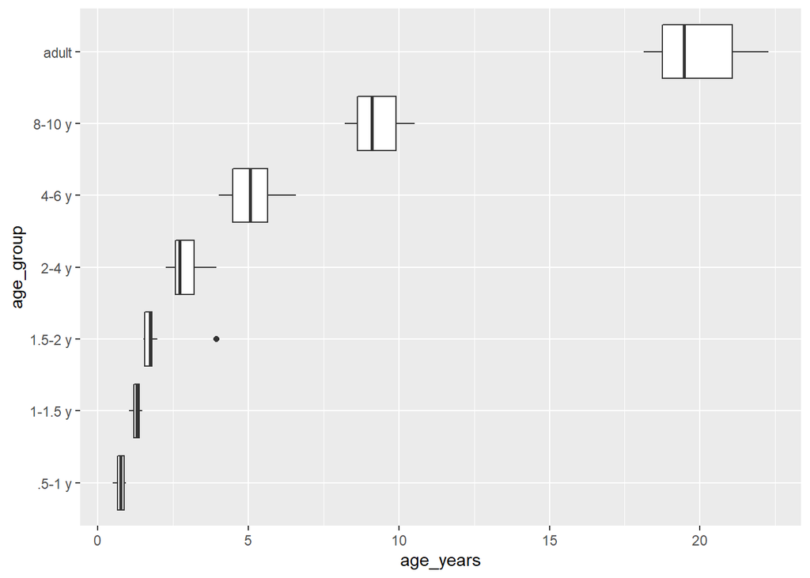

```r
ds %>% group_by(id, age_group) %>%
  summarize(age_years = mean(age_years)) %>%
  ggplot(aes(y = age_group, x = age_years)) + geom_boxplot()
```

Another option would be to facet by age group and to let the scales be “free” to get a better look

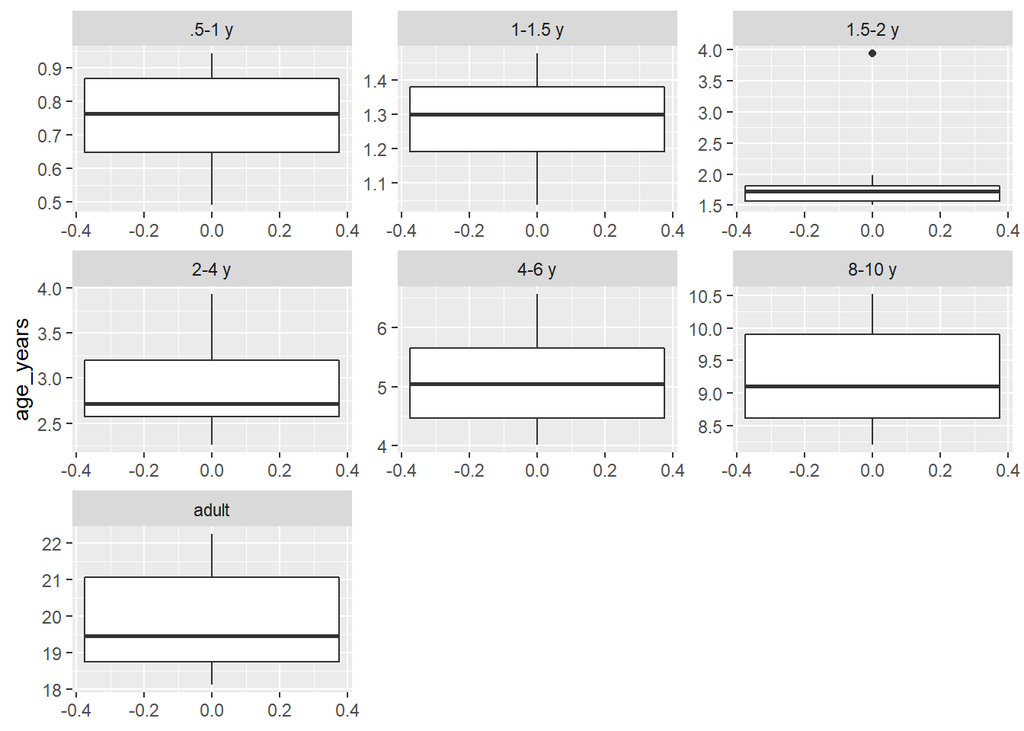

```r
ds %>% group_by(id, age_group) %>%
  summarize(age_years = mean(age_years)) %>%
  ggplot(aes(y = age_years)) +
  geom_boxplot() +
  facet_wrap("age_group", scales = "free")
```

Make a summary table of age in years by age group to check whether all participants’ ages are correct

```r
ds %>% group_by(age_group) %>% summarize(min_age = min(age_years), max_age = max(age_years))
```

```
## # A tibble: 7 x 3
##   age_group min_age max_age
##   <chr>       <dbl>   <dbl>
## 1 .5-1 y      0.493   0.942
## 2 1-1.5 y     1.04    1.48
## 3 1.5-2 y     1.51    3.94
## 4 2-4 y       2.26    3.94
## 5 4-6 y       4.02    6.57
## 6 8-10 y      8.21   10.5
## 7 adult      18.1    22.3
```